# RSECon 2024 Highlights

Joe Marsh Rossney

joemar@ceh.ac.uk

Jo Walsh

jowals@ceh.ac.uk

Matt Brown

matbro@ceh.ac.uk

Matt Coole

matcoo@ceh.ac.uk

Wednesday, November 6, 2024

# Joe’s highlights

### CodeRefinery workshops

> *“We train you in research software development”*

coderefinery.org | github.com/coderefinery | [nordic-rse.org](https://nordic-rse.org/)

- Live-streamed workshops on twitch, similar to [the carpentries](https://carpentries.org/index.html)
- Hybrid ‘bring your own classroom’ format - like a ‘watch party’
- Previous workshops uploaded to youtube.com/@coderefinery3414
- Publically funded (by Nordic research council), run as a community project
- They seem incredibly open and seeking collaboration, see e.g. [coderefinery.org/tasks](https://coderefinery.org/tasks/)

#### For RSEs & other instructors…

- They run instructor training workshops (help us become better teachers)
- RSEs could provide workshops via their platform, so that our colleagues at other organisations can benefit

### Carbon cost of software

#### Carbon cost calculator from [green-algorithms.org](https://www.green-algorithms.org/)

- Input details of algorithm, runtime, hardware to get a CO<sub>2</sub> estimate
- Inevitably *very* large errors on estimates, particularly for HPC
- See [doi.org/10.1002/advs.202100707](https://onlinelibrary.wiley.com/doi/10.1002/advs.202100707) for methodology

#### A Python package codecarbon.io for *in situ* estimates

- Speaker (from STFC) used `codecarbon` to add CO<sub>2</sub> estimate to existing tool for benchmarking optimisation algorithms: [github.com/fitbenchmarking](https://github.com/fitbenchmarking/fitbenchmarking)

#### An HPC case study ([archer2.ac.uk](https://www.archer2.ac.uk/))

- Surprising claim: energy efficiency is the wrong metric as renewables increasingly dominate electricity generation.
- Instead, aim to maximise life-span and system utilisation.
- ARCHER 2 aiming to provide emissions info to users (Jasmin could do the same!)

### Reproducible development environments

- Speaker reported on their experience using jetify.com/devbox, a CLT for generating dev isolated dev environments based on NixOS (see [nixos.org](https://nixos.org/))
- Just modifies `$PATH` (no virtualisation) — very similar to `cargo`, `poetry`, `pixi` in both principle and practice
- `devbox.lock` contains everything needed to reproduce environment *exactly*

```bash
devbox init  # creates devbox.json
devbox add git  # installs git@latest & adds it to devbox.json
devbox add python@3.12  # same for Python 3.12
devbox shell  # activates the shell
```

- Nix lets you build an entire OS deterministically from a configuration file — consistent environment on local host, CI, VM
- Unfortunately Nix does not build packages with non-free backends, so e.g. PyTorch with MKL & CUDA is difficult and tedious
- Doesn’t work on Windows

### Notable mentions

#### Weather & climate RSEs - discussion

- Participants made notes during the session: hackmd.io/W9YAQowdSSqJ2RELJEd5tw
- Join the new channel `#geoscience` in [ukrse.slack.com](https://ukrse.slack.com/)
- Subscribe to the mailing list using the google form here: tinyurl.com/49x7c4fc
- Join the Special Interest Group using the same form

#### Framework for scaling up reproducible practices in research organisations

- Framework (zenodo.org/records/10664660) based on a mixed-methods study zenodo.org/records/10663903
- Dimensions considered: tools, training, incentives, mentors, feedback, expert involvement, policies and procedures
- In most cases the interesting and difficult part is the ‘scaling up’ part!
- Also discussed ‘good enough practices in scientific computing’ — doi.org/10.1371/journal.pcbi.1005510

# Jo’s highlights

### “Scaling reproducibility” influencing change workshop

- Discussion-focused look at the detail of [the framework](https://zenodo.org/records/10664660)
- Assess your org’s maturity levels against different criteria:
- ‘Locus of leadership’, ‘Communities of Practise’, ‘Tools’, ‘Education and training’, ‘Incentives’, ‘Modelling and mentoring’, ‘Review and feedback’, ‘Expert involvement’, ‘Policies and procedures’
- Helps pick where to focus effort for most payoff of impact
- Helps map a path about where to improve, without despairing where you are now
- Leaves you reflecting that the benefits of RSE work are more culture than code

### Mutation testing - who tests the testers?

- Met Office use of [mutmut](https://mutmut.readthedocs.io/en/latest/index.html) to stress their python tests
- In essence, change the meaning of one line of code, if the tests still pass, they’re weak
- Helps think twice about what your code is doing, not only how you’re testing
- Useful for big legacy codebases as well as new work

### “Reproducible distributed research in practice”

- Next-level approach to distributed data-versioning and workflow tools
- Active development by [RESIDE](https://reside-ic.github.io/) group at the MRC Centre at Imperial
- “leans on metaphors from containerisation” - best of git, docker and `{targets}`
- Language-agnostic, with a `[pyorderly](https://github.com/mrc-ide/pyorderly)` equivalent to R’s `orderly`

### Special mentions!

- The [YeSTEM Equity Compass](https://yestem.org/tools/the-equity-compass/) from the opening keynote
- Early morning classes! Bhangra dancing, meditation
- Quiet Room for neurodiverse people to decompress in
- Lots of potential for more conversational, self-organising activity

# Matt B’s highlights

### Highlights

- [Document checklist/assessment criteria](https://docs.google.com/document/d/1NuBSkRCY3wpLmuM0kGmZA8wPxTnqu4Ow6B-Ay1_vgoM/edit) and worksheet for where organisations are for software reproducibility (Jo already covered nicely)
- [RO-Crate](https://www.researchobject.org/ro-crate/). A way of packaging metadata and provenance with data. Could be useful for FDRI. Follow up with a [previous assessment](https://wiki.ceh.ac.uk/display/ad/ro-crate) of it conducted in the EDS team. [(Py)orderly](https://github.com/mrc-ide/pyorderly) is in a similar space too (already covered)
- Great conversation with friendly folk at UKAEA, have had an RSE group for ~7years, very willing to help us set up ours

### The importance of boilerplate code

- A reminder that this code can make big impacts!
- Tricky to install? Use a CI workflow on GH to automatically upload to pypi
- Hard to get (small) inputs into code? Collect in a data repository and auto-download from code
- Doesn’t work in X language? Write a wrapper around the code in X language
- Some nice things to bear in mind in our work

### Training resources

- Some [performance and profiling training resources](https://rse.shef.ac.uk/pando-python/index.html) which are nice-to-haves, something we can point out when reviewing code, use in our best practices when developing code and fold into any training where appropriate
- Some [testing training resources](https://github.com/abhidg/advanced-python-testing)
- Some [FAIR4RS (FAIR for Research Software) training resources](https://carpentries-incubator.github.io/fair-research-software/00-introduction.html)
- [Coderefinery](https://www.coderefinery.org) “bring your own classroom” approach (mentioned by Joe earlier)

### Working with object storage and gridded data

- Work at NOC that has close parallels with what I am trying to do in FDRI. [Presentation](https://docs.google.com/presentation/d/18RZSS0LEIYOHK0Qhh_UWaCh00lhfXlfO/edit#slide=id.p1) here, [streamlit-based visualisation app](https://github.com/NOC-OI/class_streamlit_zarr) here, cute little command line application aiming to simplify the netcdf -> rechunk -> zarr pipeline [here](https://github.com/NOC-OI/msm-os).
- They also have a Data Science Platform that’d it’d be good to get to know better. Meeting being arranged!

### Honourable mentions

- [A name change policy working group](https://ncpwg.org/resources/authors/) aiming to make it easier for researchers to change their names and not be harmed by it, given academia’s focus on your publishing/contribution record
- Which was mentioned in an EEDI “Birds of a Feather” session which had lots of other great inclusivity ideas! Notes from the session to be dsitributed once anonymised.
- The friendly and accommodating vibe!

# Matt C’s highlights

### Technical Presentations

- Performant Python Patterns ([Robert Chisholm](https://github.com/Robadob))
  - [Python Profiling (Carpentries)](https://rse.shef.ac.uk/pando-python/)
  - Incredible performance of python built ins.
- Advanced Python Testing ([Abhishek Dasgupta](https://github.com/abhidg))
  - [`hypothesis`](https://hypothesis.works/)
  - [`syrupy`](https://github.com/syrupy-project/syrupy)
- Demystifying Large Language Models ([Martin O’Reilly](https://github.com/martintoreilly))
  - Shortcomings with bias, hallucinations, snapshot in time.
  - Dificulties in evaluating performance.

### Agile Methods for RSEs

#### Manchester University ([Ann Gledson](https://github.com/AnnAnnFryingPan), [Adrian Harwood](https://github.com/aharwood2))

- Manchester Universities approach to managing projects using scrum and agile.
- Importance of being flexible and truly agile based on engagement from stakeholders.
- Tooling based around using github with customisations.

#### Alan Turing Institute ([Carlos Gavidia-Calderon](https://github.com/cptanalatriste))

- Turing Institute’s approach to agile - being adaptive based on projects.
- Daily stand-ups difficult with researchers - weekly (focus on what’s blocking).
- Focus on what works for your team - not what other people do.

### Cookie cutters ([Carlos Martinez-Ortiz](https://github.com/c-martinez))

- Importance of templates for helping to adopt best practise.
- Tooling beyond [Cookie Cutters](https://www.cookiecutter.io/) like [Copier](https://copier.readthedocs.io/en/stable/) which allow options and profiles.
- Lots of existing templates to build on / collaborate with
  - [Materials Data Science and Informatics Template](https://github.com/Materials-Data-Science-and-Informatics/fair-python-cookiecutter)
  - [Alan Turing Institute Template](https://github.com/alan-turing-institute/python-project-template/tree/main)

### Other highlights

- Keynote ([Anne-Marie Imafidon](https://aimafidon.com/about/))
  - [Invisible Women](https://carolinecriadoperez.com/book/invisible-women/)
- A New RSE Group - The First 100 Days ([Jo Walsh](https://github.com/metazool))
- Weather & Climate RSE Community ([Jo Marsh Rossney](https://github.com/jmarshrossney))

[figure not shown]

Jo Walsh, RSECon24

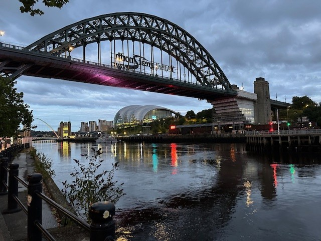

Newcastle, RSECon24

[figure not shown]

Joe Marsh Rossney, RSECon24

# Useful links

- Conference website: rsecon24.society-rse.org/
- RSE Society youtube channel: [youtube.com/@SocRSE](https://www.youtube.com/@SocRSE/)
- Our internal discussions: github.com/NERC-CEH/rse_group/discussions/40

[figure not shown]